# 03 数据统计描述、可视化与回归分析报告

本报告基于 `dshw-p01/data` 中已经下载并清洗完成的 A 股股票、市场指数、宏观指标和财务指标数据，完成描述性统计、可视化、CAPM 回归以及宏观指标敏感性分析。报告目标是回答 10 只代表性股票在样本期内的收益风险特征、行业相关性、市场风险暴露以及对 CPI 变化的敏感程度。

## 1 数据说明

样本股票共 10 只，覆盖银行、汽车、房地产、白酒和能源五个行业，每个行业选取 2 家具有代表性的上市公司。股票日行情使用后复权价格，样本区间为 2020 年初至 2026-05-22；市场基准使用沪深 300 指数，宏观指标使用 CPI 同比和 M2 同比，财务指标主要使用 2020-2024 年 ROE。

本报告的核心收益率口径为日对数收益率，即 $r_t=\ln(P_t/P_{t-1})$。使用对数收益率的优点是便于跨期累加和进行回归建模，也能更稳定地比较不同价格水平股票的收益波动。

## 2 清洗说明

数据清洗工作已在 `02_clean.ipynb` 中完成，主要包括统一字段命名、修复日期和数值类型、处理缺失值、按股票代码和交易日期排序，以及将清洗结果同时保存为 CSV 和 Parquet。清洗后的股票行情保存在 `data/clean/stock_clean.csv`，市场指数、宏观指标和财务指标分别保存在 `data/index/`、`data/macro/` 和 `data/finance/`。

在本报告中，分析前会重新读取清洗后的数据，并再次进行必要的类型校验和收益率计算。这样可以保证报告独立可复现：即使不打开前两个 Notebook，读者也能从本报告中看到数据范围、变量口径、统计方法和主要结论。

```
项目目录: C:\Users\ZhuanZ1\Desktop\个人作业1\dshw-p01
图片输出目录: C:\Users\ZhuanZ1\Desktop\个人作业1\dshw-p01\output
绘图字体: Microsoft YaHei
```

## 数据读取与预处理

```
股票日行情: 2020-01-02 至 2026-05-22，共 10 只股票
沪深300: 2020-01-02 至 2026-05-22
CPI: 2020-01 至 2025-08
```

|  | code | name | industry |
| --- | --- | --- | --- |
| 0 | 601398 | 工商银行 | 银行 |
| 1 | 600036 | 招商银行 | 银行 |
| 2 | 002594 | 比亚迪 | 汽车 |
| 3 | 600104 | 上汽集团 | 汽车 |
| 4 | 000002 | 万科A | 房地产 |
| 5 | 600048 | 保利发展 | 房地产 |
| 6 | 600519 | 贵州茅台 | 白酒 |
| 7 | 000858 | 五粮液 | 白酒 |
| 8 | 601088 | 中国神华 | 能源 |
| 9 | 600900 | 长江电力 | 能源 |

## 4.1 基本统计量

|  | 股票 | 行业 | 年化均值 | 年化波动率 | 偏度 | 峰度 | 最大回撤 |
| --- | --- | --- | --- | --- | --- | --- | --- |
| 0 | 招商银行(600036) | 银行 | 3.74% | 27.52% | 0.270 | 3.226 | -50.94% |
| 1 | 工商银行(601398) | 银行 | 8.94% | 16.23% | 0.451 | 5.775 | -20.20% |
| 2 | 比亚迪(002594) | 汽车 | 29.29% | 43.07% | 0.310 | 2.111 | -52.54% |
| 3 | 上汽集团(600104) | 汽车 | -7.87% | 31.48% | 0.348 | 5.370 | -53.99% |
| 4 | 万科A(000002) | 房地产 | -33.29% | 36.27% | 0.654 | 3.250 | -87.81% |
| 5 | 保利发展(600048) | 房地产 | -12.61% | 36.11% | 0.557 | 3.155 | -67.65% |
| 6 | 五粮液(000858) | 白酒 | -4.67% | 34.33% | 0.095 | 3.368 | -71.57% |
| 7 | 贵州茅台(600519) | 白酒 | 4.50% | 27.58% | 0.262 | 3.637 | -47.48% |
| 8 | 长江电力(600900) | 能源 | 9.33% | 17.73% | 0.370 | 3.575 | -17.54% |
| 9 | 中国神华(601088) | 能源 | 22.10% | 29.82% | 0.316 | 3.289 | -21.47% |

```
统计表已保存: C:\Users\ZhuanZ1\Desktop\个人作业1\dshw-p01\output\table1_return_stats.csv
```

上表使用日对数收益率计算，年化均值按 252 个交易日放大，年化波动率按平方根时间法换算。最大回撤反映样本期内从历史高点到后续低点的最大跌幅，能补充均值和波动率无法呈现的下行风险。

## 4.2 可视化

### 图 1：归一化收盘价走势图

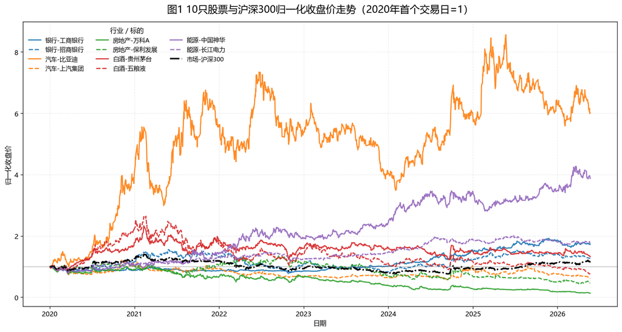

图 1 将所有标的统一到 2020 年首个交易日等于 1，因此可以直接比较不同股价水平股票的累计涨跌幅。行业内部两只股票使用同一颜色、不同线型，便于观察同一行业内部是否呈现相似走势；黑色点划线的沪深 300 则提供市场基准。

### 图 2：日收益率分布图

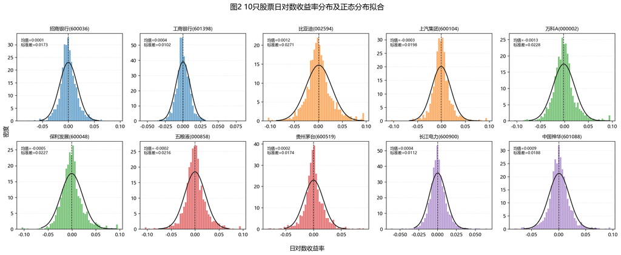

图 2 中柱状图展示实际日对数收益率分布，黑色曲线为使用样本均值和标准差拟合的正态分布。若柱状图在中心位置更尖、两端尾部更厚，说明股票收益率存在尖峰厚尾特征，单纯使用正态分布可能低估极端涨跌的概率。

### 图 3：收益率相关系数热力图

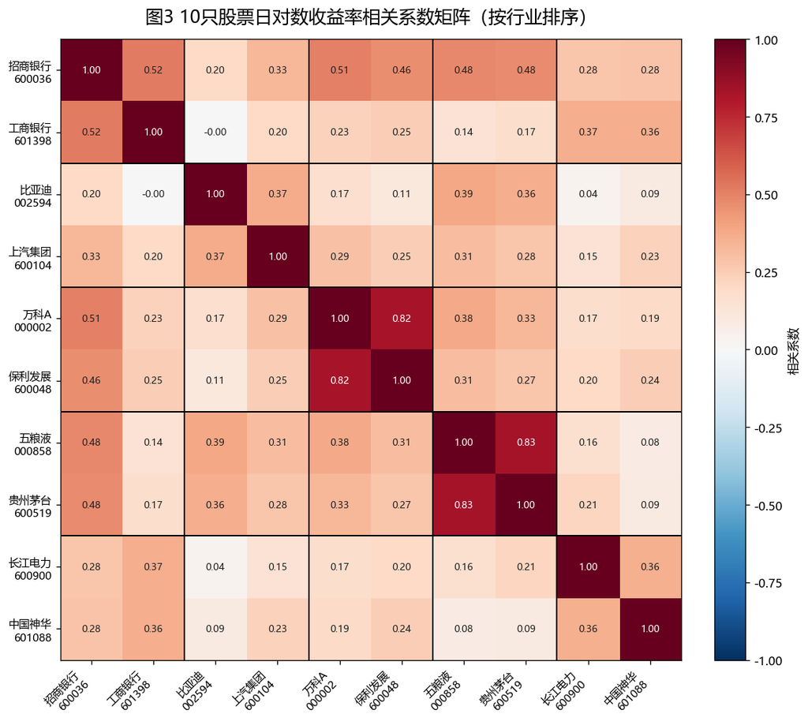

```
同行业平均相关系数: 0.580
跨行业平均相关系数: 0.251
```

图 3 按行业对股票排序，黑色分隔线框出了银行、汽车、房地产、白酒和能源五个行业块。若对角线附近同一行业块的数值整体高于跨行业区域，说明行业共同冲击较明显；若跨行业相关性也普遍较高，则反映市场系统性因素对个股收益的影响较强。

### 图 4：宏观指标与股市关系

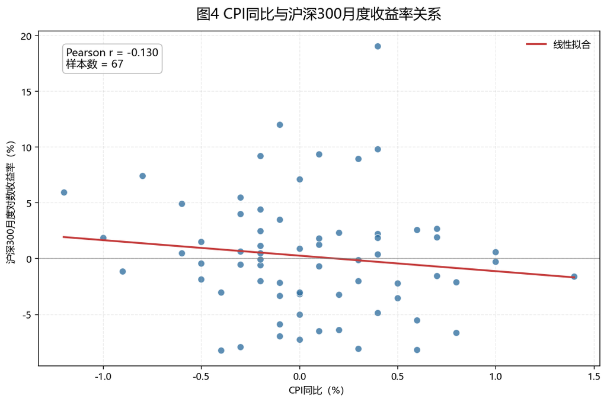

|  | month | cpi_yoy | hs300_monthly_return |
| --- | --- | --- | --- |
| 0 | 2020-02 | 1.4 | -1.607623 |
| 1 | 2020-03 | 0.8 | -6.660897 |
| 2 | 2020-04 | -1.2 | 5.961235 |
| 3 | 2020-05 | -0.9 | -1.171128 |
| 4 | 2020-06 | -0.8 | 7.398242 |

图 4 选取 CPI 同比作为宏观指标，横轴表示通胀水平，纵轴表示沪深 300 月度对数收益率。图中的 Pearson 相关系数和拟合线方向用于判断二者在线性意义上的同向或反向关系；经济含义上，通胀变化会影响货币政策预期、企业成本和估值折现率，因此其与股市收益的关系可能同时受到增长预期和政策环境影响。

### 图 5（选做）：财务指标跨公司对比

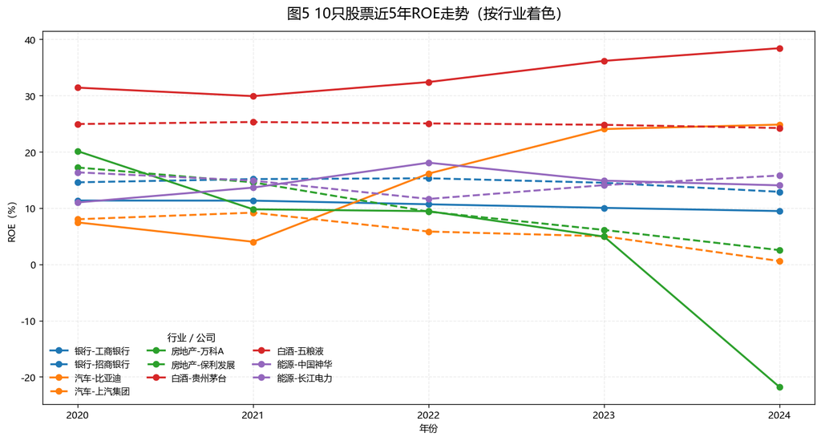

图 5 展示 2020-2024 年各公司的 ROE 变化，颜色用于区分行业，线型用于区分同一行业内的两家公司。ROE 水平较高且趋势稳定的公司通常体现更强的盈利质量和资本使用效率，而 ROE 下行明显的行业或公司可能受到景气度回落、资产周转放慢或利润率压缩的影响。

## 5 回归模型分析

本部分在前面日对数收益率的基础上继续进行回归分析。5.1 使用沪深 300 作为市场组合估计 10 只股票的 CAPM Beta；5.2 选取 CPI 同比作为宏观变量，分析其对股票月度收益率的影响。

### 5.1 CAPM 模型估计

CAPM 模型设定为：

$$r_{i,t}-r_f=\alpha_i+\beta_i(r_{m,t}-r_f)+\varepsilon_{i,t}$$

其中个股收益率和市场收益率均使用日对数收益率，无风险利率统一设为年化 2.0%，日频换算为 $r_f^{daily}=0.02/252$。

|  | 股票 | 行业 | Alpha | Alpha p值 | Beta | 95% CI | R2 |
| --- | --- | --- | --- | --- | --- | --- | --- |
| 0 | 招商银行(600036) | 银行 | 0.000051 | 0.8846 | 0.892 | [0.834, 0.950] | 0.371 |
| 1 | 工商银行(601398) | 银行 | 0.000271 | 0.2824 | 0.215 | [0.174, 0.257] | 0.062 |
| 2 | 比亚迪(002594) | 汽车 | 0.001057 | 0.0659 | 1.273 | [1.178, 1.368] | 0.309 |
| 3 | 上汽集团(600104) | 汽车 | -0.000409 | 0.3481 | 0.844 | [0.772, 0.917] | 0.255 |
| 4 | 万科A(000002) | 房地产 | -0.001421 | 0.0042 | 1.006 | [0.924, 1.088] | 0.272 |
| 5 | 保利发展(600048) | 房地产 | -0.000597 | 0.2496 | 0.855 | [0.769, 0.941] | 0.198 |
| 6 | 五粮液(000858) | 白酒 | -0.000291 | 0.4617 | 1.272 | [1.206, 1.337] | 0.485 |
| 7 | 贵州茅台(600519) | 白酒 | 0.000080 | 0.8117 | 0.962 | [0.907, 1.017] | 0.430 |
| 8 | 长江电力(600900) | 能源 | 0.000286 | 0.3003 | 0.224 | [0.178, 0.270] | 0.056 |
| 9 | 中国神华(601088) | 能源 | 0.000790 | 0.0881 | 0.401 | [0.325, 0.478] | 0.064 |

```
CAPM 结果表已保存: C:\Users\ZhuanZ1\Desktop\个人作业1\dshw-p01\output\table2_capm_results.csv
```

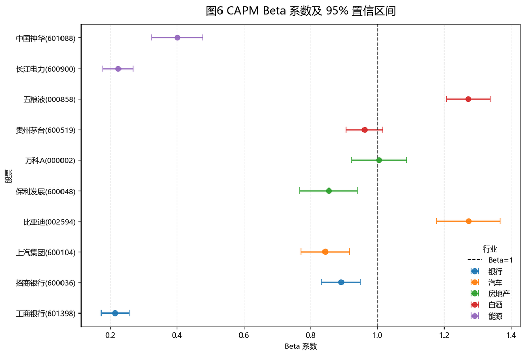

Beta 大于 1 的股票包括 比亚迪（汽车，β=1.27）、五粮液（白酒，β=1.27）、万科A（房地产，β=1.01），主要涉及 汽车、白酒、房地产。Beta 高于 1 表明这些股票相对市场组合更敏感，若它们集中在汽车、房地产等更受经济周期和风险偏好影响的行业，通常与周期性行业特征较吻合；若出现在白酒或能源等行业，则说明样本期内公司自身景气变化或估值波动也可能放大了市场敏感性。

以 5% 显著性水平看，Alpha 显著异于零的股票为 万科A（α=-0.00142, p=0.004）。Alpha 显著意味着在扣除无风险收益并控制市场超额收益后，个股仍存在 CAPM 无法解释的超额收益或异常收益，但这也可能来自遗漏变量、行业风险暴露或样本期事件冲击。

R² 最高的是 五粮液（白酒，R²=0.485），说明其日收益率中由沪深 300 市场收益解释的比例最高，市场系统性因素对它的影响更强。R² 最低的是 长江电力（能源，R²=0.056），说明该股票收益中公司自身因素、行业独立冲击或非市场因素占比更高，单一市场因子解释力较弱。

图 6 用点估计和误差棒同时展示 Beta 的大小与估计不确定性，竖线 $\beta=1$ 表示与沪深 300 市场组合具有相同系统性风险。误差棒越短说明 Beta 估计越精确；若置信区间整体位于 1 的右侧或左侧，则可以更有把握地判断该股票相对市场更激进或更防御。

### 5.2 宏观指标对股票收益率的影响（选做）

本部分选取 CPI 同比作为宏观指标，使用月度数据估计：

$$r_{i,t}^{月}=\alpha_i+\gamma_i \cdot CPI_t+\varepsilon_{i,t}$$

其中月度股票收益率由月末收盘价计算得到，CPI 同比单位为百分比。$\gamma_i$ 表示 CPI 同比每上升 1 个百分点时，该股票月度收益率的平均变化。

|  | 股票 | 行业 | Gamma | Gamma p值 | 95% CI | R2 | 样本数 |
| --- | --- | --- | --- | --- | --- | --- | --- |
| 0 | 招商银行(600036) | 银行 | -1.880 | 0.3578 | [-5.936, 2.175] | 0.013 | 67 |
| 1 | 工商银行(601398) | 银行 | -1.262 | 0.1524 | [-3.001, 0.478] | 0.031 | 67 |
| 2 | 比亚迪(002594) | 汽车 | -0.754 | 0.8101 | [-6.992, 5.485] | 0.001 | 67 |
| 3 | 上汽集团(600104) | 汽车 | -0.719 | 0.7377 | [-4.987, 3.549] | 0.002 | 67 |
| 4 | 万科A(000002) | 房地产 | 3.598 | 0.1753 | [-1.646, 8.842] | 0.028 | 67 |
| 5 | 保利发展(600048) | 房地产 | 2.307 | 0.3630 | [-2.723, 7.337] | 0.013 | 67 |
| 6 | 五粮液(000858) | 白酒 | -2.971 | 0.2673 | [-8.276, 2.333] | 0.019 | 67 |
| 7 | 贵州茅台(600519) | 白酒 | -1.718 | 0.4265 | [-6.006, 2.570] | 0.010 | 67 |
| 8 | 长江电力(600900) | 能源 | -0.391 | 0.7470 | [-2.802, 2.020] | 0.002 | 67 |
| 9 | 中国神华(601088) | 能源 | 1.479 | 0.4152 | [-2.123, 5.080] | 0.010 | 67 |

```
CPI 月度回归结果表已保存: C:\Users\ZhuanZ1\Desktop\个人作业1\dshw-p01\output\table3_cpi_monthly_regression.csv
```

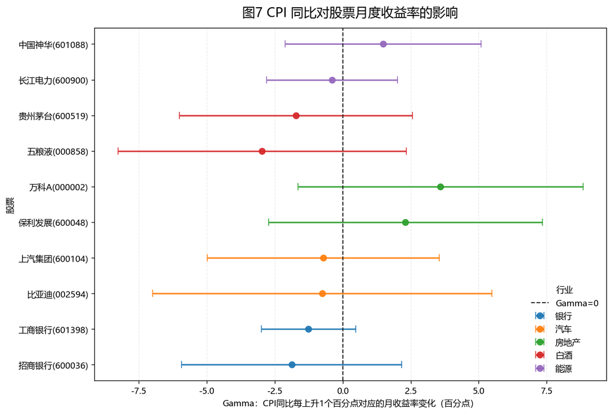

以 5% 显著性水平看，CPI 同比对 10 只股票月度收益率的 Gamma 估计均未显著异于零，说明在当前样本中很难确认 CPI 对单只股票月度收益具有稳定线性影响。月度样本数量相对有限，且股票收益还会同时受到盈利预期、政策预期和市场风险偏好等因素影响，因此单变量宏观回归的解释力通常较弱。

从行业平均 Gamma 看，房地产 的 CPI 敏感性相对最偏正向，白酒 的敏感性相对最偏负向。若 CPI 上行代表需求改善，消费或资源类行业可能受益；但若 CPI 上行强化紧缩政策和成本压力预期，估值较敏感或成本传导能力较弱的行业可能承压。

因此，不同行业对 CPI 的反应取决于通胀背后的经济含义：需求拉动型通胀可能改善收入和利润预期，成本推动型通胀则可能压缩利润率并提高折现率。对于银行、能源、消费、汽车和房地产等行业，盈利模式、负债结构、价格传导能力和政策敏感度不同，会导致宏观指标回归系数出现方向和强度差异。

图 7 展示 CPI 同比对各股票月度收益率影响系数 $\gamma$ 的点估计和 95% 置信区间，竖线 $\gamma=0$ 表示宏观指标对收益率没有线性影响。点位在 0 右侧表示 CPI 上行与股票月度收益率上升相联系，点位在 0 左侧则表示二者呈负向关系；置信区间越宽，说明月度样本下估计不确定性越高。

## 6 结论

综合描述性统计和可视化结果，10 只股票在样本期内呈现出明显的行业差异：同一行业股票在价格走势、收益分布和相关性上通常更接近，而跨行业之间的风险来源和波动节奏差异更明显。归一化价格走势和 ROE 对比也显示，股票收益不仅受市场整体波动影响，还与行业景气、公司盈利质量和估值变化密切相关。

CAPM 回归进一步刻画了各股票相对于沪深 300 的系统性风险暴露。Beta 大于 1 的股票代表对市场波动更敏感，通常更接近周期性或高弹性资产；Alpha 是否显著则用于判断在控制市场风险后是否仍存在异常收益。R² 的高低反映沪深 300 这一单一市场因子对个股收益的解释力，R² 较低的股票更可能受到公司特质、行业政策或独立事件冲击影响。

宏观指标分析以 CPI 同比为例，结果用于观察通胀变化与股票月度收益之间的线性关系。由于月度样本数量有限，且股票收益同时受到盈利预期、政策预期、流动性和风险偏好影响，CPI 单变量回归更适合作为敏感性分析而非因果判断。总体而言，本报告说明了从数据清洗、统计描述、图表展示到回归建模的一套完整金融数据分析流程。

## 输出文件检查

运行完本 Notebook 后，`output/` 目录应包含图 1 至图 7 的 PNG 文件，以及基本统计量、CAPM、CPI 月度回归结果 CSV 表。

```
fig1_normalized_close.png 491.1 KB
fig2_return_dist.png 315.8 KB
fig3_corr_heatmap.png 259.5 KB
fig4_cpi_vs_index.png 102.9 KB
fig5_roe_trend.png 204.9 KB
fig6_capm_beta.png 138.0 KB
fig7_cpi_gamma.png 148.9 KB
table1_return_stats.csv 1.3 KB
table2_capm_results.csv 1.8 KB
table3_cpi_monthly_regression.csv 1.6 KB
```